# French Films Profitability: CRISP-DM Analysis & Quality Diagnostic

Smart Analytics for Big Data — Lesson 02 (Intermediate Activity)

Riccardo Fanton

2026-09-29

# 1 Executive Summary & Business Question

## 1.1 Project Overview

This dynamic analysis addresses the **Intermediate Level** requirement of *Smart Analytics for Big Data (Lesson 02)*. We evaluate the financial and operational drivers of **French film profitability** using historical box office and production metadata.

The study adheres strictly to the **CRISP-DM** (*Cross-Industry Standard Process for Data Mining*) methodology, integrating data quality diagnostics and econometric modeling.

## 1.2 Scientific & Business Questions

1. **Business Question (Management Perspective):** > *How do pre-production capital allocation (budget) and runtime duration determine the net box-office profit of French film productions, and how can studio executives set empirical budget boundaries to minimize the risk of heavy financial losses?*
2. **Scientific & Econometric Question (Statistical Perspective):** > *What is the marginal impact of budget ($\beta_1$) and duration ($\beta_2$) on net profit in the multiple linear regression model:*
   $$\text{profit}_i = \alpha + \beta_1 \cdot
   \text{budget}_i + \beta_2 \cdot \text{duration}_i +
   \varepsilon_i$$
   *Is the relationship between budget and profit positive and statistically significant, or does aggressive scaling lead to diminishing or negative returns?*
3. **Key Stakeholders / Clients:**
   - **Primary Decision-Maker**: Film Production Executives and Studio Financiers (*Gaumont, Pathé, Studiocanal*) who make script greenlighting and budget allocation decisions.
   - **Co-Funders & Public Bodies**: The *CNC* (*Centre National du Cinéma et de l’Image Animée*) and media investment vehicles (*SOFICA*).

# 2 CRISP-DM Framework Architecture

```
+-------------------------------------------------------------------------------+
|                             CRISP-DM LIFECYCLE                                |
+-------------------------------------------------------------------------------+
| 1. Business Understanding   -> Define ROI & Profit targets for French films    |
| 2. Data Understanding       -> Extract French subset, audit missingness & types|
| 3. Data Preparation         -> Currency rescaling (Millions $), clean records  |
| 4. Modeling                 -> OLS Regressions (Model 1, Model 2, Model 3)    |
| 5. Evaluation               -> Goodness-of-fit (R²), t-tests, residual checks  |
| 6. Deployment               -> Dynamic RMarkdown scoring report & rules        |
+-------------------------------------------------------------------------------+
```

# 3 Data Ingestion & Setup

We load the required analytics libraries and import the historical film database.

```r
# Load essential data science packages
library(ggplot2)
library(dplyr)
library(knitr)
library(skimr)
```

```r
# Locate and load the dataset (supports relative and absolute paths)
data_path <- "../data/Movie.Data.DE.RData"
if (!file.exists(data_path)) {
  data_path <- "/Users/riccardofanton/Documents/Visual Studio Code/01_ACTIVE_PROJECTS/0 - VS POLI/02_GRENOBLE_INP_3A/2 - Smart Analytics for Big Data/notebooks/app1_movies/data/Movie.Data.DE.RData"
}
load(data_path)

# Filter exclusively for French productions
FrenchFilms <- Movie.Data.DE[!is.na(Movie.Data.DE$country) & Movie.Data.DE$country == "France", ]

# Rescale financial variables to Millions of USD ($M) for readable regression estimates
FrenchFilms$budget_M <- FrenchFilms$budget / 1e6
FrenchFilms$profit_M <- FrenchFilms$profit / 1e6
FrenchFilms$is_profitable <- ifelse(FrenchFilms$profit > 0, "Profitable", "Loss-Making")

cat("Full dataset observations:", nrow(Movie.Data.DE), "\n")
```

```
## Full dataset observations: 4917
```

```r
cat("French film sample size  :", nrow(FrenchFilms), "\n")
```

```
## French film sample size  : 154
```

# 4 Data Understanding & Quality Diagnostic

Before estimating econometric models, we execute a data quality audit (missing values, types, distribution shape).

## 4.1 Dataset Structure

```r
str(FrenchFilms)
```

```
## 'data.frame':    154 obs. of  9 variables:
##  $ country      : Factor w/ 66 levels "","Afghanistan",..: 21 21 21 21 21 21 21 21 21 21 ...
##  $ title_year   : int  2008 2010 1997 2015 2006 2009 2015 2005 2004 1998 ...
##  $ budget       : num  7.8e+07 1.0e+08 9.3e+07 NA 8.6e+07 ...
##  $ profit       : num  NA -64975525 -29459980 NA -70868670 ...
##  $ duration     : int  116 115 126 81 94 104 108 163 109 143 ...
##  $ color        : Factor w/ 3 levels ""," Black and White",..: 3 3 3 3 3 3 3 3 3 3 ...
##  $ budget_M     : num  78 100 93 NA 86 ...
##  $ profit_M     : num  NA -65 -29.5 NA -70.9 ...
##  $ is_profitable: chr  NA "Loss-Making" "Loss-Making" NA ...
```

## 4.2 Missing Values & Summary Statistics

```r
# Missing value check per column
missing_audit <- colSums(is.na(FrenchFilms))
kable(as.data.frame(t(missing_audit)), caption = "Count of Missing Values per Attribute (French Sample)")
```

Count of Missing Values per Attribute (French Sample)

| country | title_year | budget | profit | duration | color | budget_M | profit_M | is_profitable |
| --- | --- | --- | --- | --- | --- | --- | --- | --- |
| 0 | 2 | 24 | 48 | 0 | 0 | 24 | 48 | 48 |

```r
# Numeric summaries
summary(FrenchFilms[, c("budget_M", "profit_M", "duration", "title_year")])
```

```
##     budget_M           profit_M            duration       title_year
##  Min.   :  0.0045   Min.   :-375.8687   Min.   : 52.0   Min.   :1964
##  1st Qu.:  9.1250   1st Qu.: -25.3248   1st Qu.: 94.0   1st Qu.:2002
##  Median : 19.7150   Median :  -9.2503   Median :105.0   Median :2006
##  Mean   : 30.6720   Mean   : -15.6169   Mean   :108.9   Mean   :2005
##  3rd Qu.: 40.0000   3rd Qu.:  -0.4653   3rd Qu.:118.0   3rd Qu.:2011
##  Max.   :390.0000   Max.   : 120.0010   Max.   :334.0   Max.   :2016
##  NAs    :24         NAs    :48                          NAs    :2
```

## 4.3 Skimr Diagnostic Table

```r
skim(FrenchFilms[, c("budget_M", "profit_M", "duration", "title_year")])
```

Data summary

| Name | FrenchFilms[, c(“budget_M… |
| --- | --- |
| Number of rows | 154 |
| Number of columns | 4 |
| _______________________ |  |
| Column type frequency: |  |
| numeric | 4 |
| ________________________ |  |
| Group variables | None |

**Variable type: numeric**

| skim_variable | n_missing | complete_rate | mean | sd | p0 | p25 | p50 | p75 | p100 | hist |
| --- | --- | --- | --- | --- | --- | --- | --- | --- | --- | --- |
| budget_M | 24 | 0.84 | 30.67 | 42.56 | 0.00 | 9.12 | 19.72 | 40.00 | 390 | ▇▁▁▁▁ |
| profit_M | 48 | 0.69 | -15.62 | 51.38 | -375.87 | -25.32 | -9.25 | -0.47 | 120 | ▁▁▁▇▁ |
| duration | 0 | 1.00 | 108.94 | 27.85 | 52.00 | 94.00 | 105.00 | 118.00 | 334 | ▇▆▁▁▁ |
| title_year | 2 | 0.99 | 2004.91 | 9.34 | 1964.00 | 2001.75 | 2006.00 | 2011.00 | 2016 | ▁▁▁▅▇ |

# 5 Exploratory Data Analysis (EDA)

## 5.1 Profitability & Financial Health

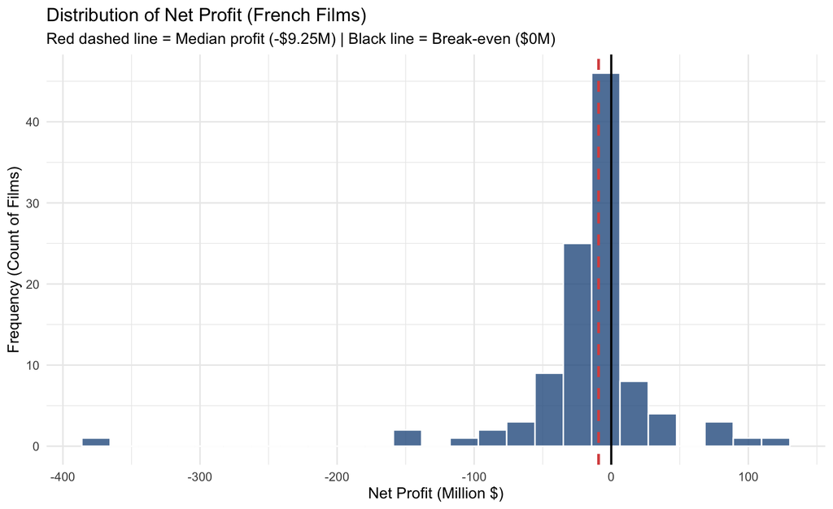

```r
# Distribution of Net Profit
ggplot(FrenchFilms, aes(x = profit_M)) +
  geom_histogram(bins = 25, fill = "#2b5c8f", color = "white", alpha = 0.8) +
  geom_vline(aes(xintercept = median(profit_M, na.rm = TRUE)), color = "#d9534f", linetype = "dashed", size = 1) +
  geom_vline(xintercept = 0, color = "black", linetype = "solid", size = 0.8) +
  labs(
    title = "Distribution of Net Profit (French Films)",
    subtitle = "Red dashed line = Median profit (-$9.25M) | Black line = Break-even ($0M)",
    x = "Net Profit (Million $)",
    y = "Frequency (Count of Films)"
  ) +
  theme_minimal(base_size = 12)
```

## 5.2 Budget vs. Profit Breakdown

```r
# Share of profitable vs loss-making productions
profit_summary <- table(FrenchFilms$is_profitable)
kable(as.data.frame(profit_summary), col.names = c("Status", "Film Count"), caption = "Profitability Breakdown")
```

Profitability Breakdown

| Status | Film Count |
| --- | --- |
| Loss-Making | 82 |
| Profitable | 24 |

# 6 Econometric Modeling (OLS Regression)

## 6.1 Model 1: Single-Variable OLS ($\text{Profit} \sim \text{Budget}$)

We test whether higher budget allocation systematically drives higher profit:
$$\text{profit}_M = \alpha_1 +
\beta_1 \cdot \text{budget}_M + \varepsilon$$

```r
model_1 <- lm(profit_M ~ budget_M, data = FrenchFilms)
summary(model_1)
```

```
##
## Call:
## lm(formula = profit_M ~ budget_M, data = FrenchFilms)
##
## Residuals:
##     Min      1Q  Median      3Q     Max
## -28.602 -16.131 -12.134   4.954 127.220
##
## Coefficients:
##             Estimate Std. Error t value Pr(>|t|)
## (Intercept) 16.07190    3.46957   4.632 1.05e-05 ***
## budget_M    -0.93164    0.06093 -15.289  < 2e-16 ***
## ---
## Signif. codes:  0 '***' 0.001 '**' 0.01 '*' 0.05 '.' 0.1 ' ' 1
##
## Residual standard error: 28.65 on 104 degrees of freedom
##   (48 observations deleted due to missingness)
## Multiple R-squared:  0.6921, Adjusted R-squared:  0.6891
## F-statistic: 233.8 on 1 and 104 DF,  p-value: < 2.2e-16
```

### 6.1.1 Visualizing Model 1

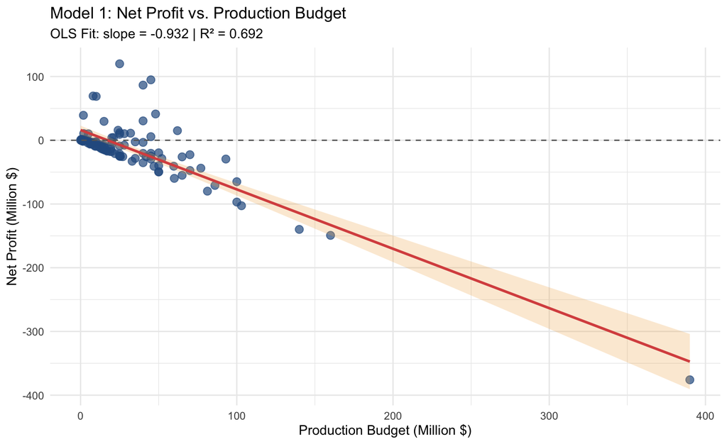

```r
ggplot(FrenchFilms, aes(x = budget_M, y = profit_M)) +
  geom_point(color = "#2b5c8f", size = 3, alpha = 0.7) +
  geom_smooth(method = "lm", color = "#d9534f", fill = "#f0ad4e", alpha = 0.25) +
  geom_hline(yintercept = 0, linetype = "dashed", color = "gray40") +
  labs(
    title = "Model 1: Net Profit vs. Production Budget",
    subtitle = paste0("OLS Fit: slope = ", round(coef(model_1)[2], 3), " | R² = ", round(summary(model_1)$r.squared, 3)),
    x = "Production Budget (Million $)",
    y = "Net Profit (Million $)"
  ) +
  theme_minimal(base_size = 12)
```

## 6.2 Model 2: Operational OLS ($\text{Profit} \sim \text{Duration}$)

We evaluate the influence of film runtime (in minutes) on profitability:
$$\text{profit}_M = \alpha_2 +
\beta_2 \cdot \text{duration} + \varepsilon$$

```r
model_2 <- lm(profit_M ~ duration, data = FrenchFilms)
summary(model_2)
```

```
##
## Call:
## lm(formula = profit_M ~ duration, data = FrenchFilms)
##
## Residuals:
##     Min      1Q  Median      3Q     Max
## -334.48   -8.54    4.28   14.37  126.12
##
## Coefficients:
##             Estimate Std. Error t value Pr(>|t|)
## (Intercept)  44.3248    25.3168   1.751   0.0829 .
## duration     -0.5425     0.2248  -2.413   0.0176 *
## ---
## Signif. codes:  0 '***' 0.001 '**' 0.01 '*' 0.05 '.' 0.1 ' ' 1
##
## Residual standard error: 50.24 on 104 degrees of freedom
##   (48 observations deleted due to missingness)
## Multiple R-squared:  0.05301,    Adjusted R-squared:  0.04391
## F-statistic: 5.822 on 1 and 104 DF,  p-value: 0.01758
```

### 6.2.1 Visualizing Model 2

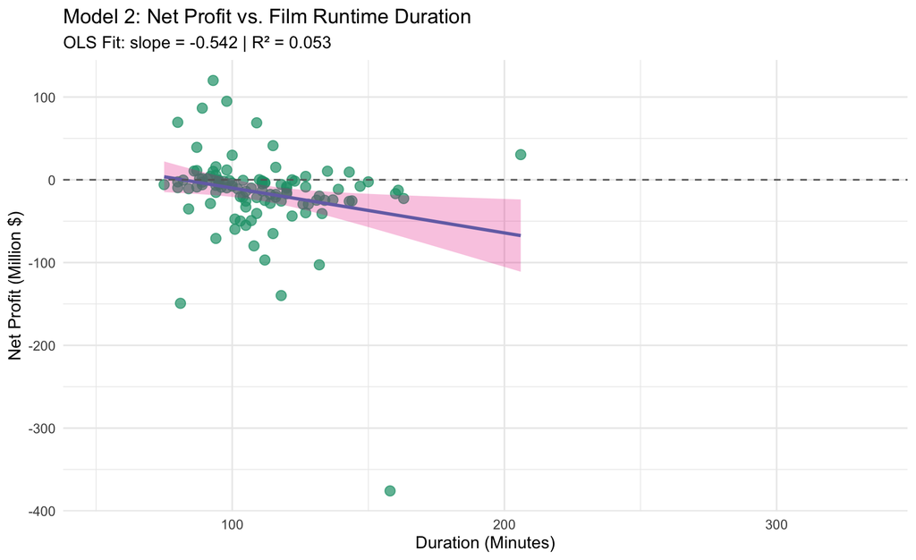

```r
ggplot(FrenchFilms, aes(x = duration, y = profit_M)) +
  geom_point(color = "#1b9e77", size = 3, alpha = 0.7) +
  geom_smooth(method = "lm", color = "#7570b3", fill = "#e7298a", alpha = 0.25) +
  geom_hline(yintercept = 0, linetype = "dashed", color = "gray40") +
  labs(
    title = "Model 2: Net Profit vs. Film Runtime Duration",
    subtitle = paste0("OLS Fit: slope = ", round(coef(model_2)[2], 3), " | R² = ", round(summary(model_2)$r.squared, 3)),
    x = "Duration (Minutes)",
    y = "Net Profit (Million $)"
  ) +
  theme_minimal(base_size = 12)
```

## 6.3 Model 3: Multivariate OLS ($\text{Profit} \sim \text{Budget} + \text{Duration}$)

Combining financial and operational parameters controls for confounding effects:
$$\text{profit}_M =
\alpha_0 + \beta_1 \cdot \text{budget}_M + \beta_2 \cdot \text{duration}
+ \varepsilon$$

```r
model_3 <- lm(profit_M ~ budget_M + duration, data = FrenchFilms)
summary(model_3)
```

```
##
## Call:
## lm(formula = profit_M ~ budget_M + duration, data = FrenchFilms)
##
## Residuals:
##     Min      1Q  Median      3Q     Max
## -28.574 -16.131 -12.127   4.775 126.974
##
## Coefficients:
##             Estimate Std. Error t value Pr(>|t|)
## (Intercept) 17.67193   14.61899   1.209    0.229
## budget_M    -0.92971    0.06358 -14.623   <2e-16 ***
## duration    -0.01507    0.13376  -0.113    0.910
## ---
## Signif. codes:  0 '***' 0.001 '**' 0.01 '*' 0.05 '.' 0.1 ' ' 1
##
## Residual standard error: 28.78 on 103 degrees of freedom
##   (48 observations deleted due to missingness)
## Multiple R-squared:  0.6921, Adjusted R-squared:  0.6862
## F-statistic: 115.8 on 2 and 103 DF,  p-value: < 2.2e-16
```

# 7 Model Comparison & Quality Diagnostics

## 7.1 Comparative Synthesis Table

```r
comparison_df <- data.frame(
  Model = c("Model 1 (Budget)", "Model 2 (Duration)", "Model 3 (Budget + Duration)"),
  Intercept = c(round(coef(model_1)[1], 2), round(coef(model_2)[1], 2), round(coef(model_3)[1], 2)),
  Slope_Budget = c(round(coef(model_1)[2], 3), NA, round(coef(model_3)[2], 3)),
  Slope_Duration = c(NA, round(coef(model_2)[2], 3), round(coef(model_3)[3], 3)),
  R_Squared = c(round(summary(model_1)$r.squared, 4), round(summary(model_2)$r.squared, 4), round(summary(model_3)$r.squared, 4)),
  Adj_R_Squared = c(round(summary(model_1)$adj.r.squared, 4), round(summary(model_2)$adj.r.squared, 4), round(summary(model_3)$adj.r.squared, 4)),
  F_Statistic = c(round(summary(model_1)$fstatistic[1], 2), round(summary(model_2)$fstatistic[1], 2), round(summary(model_3)$fstatistic[1], 2))
)

kable(comparison_df, caption = "Econometric Comparison Across Linear Models")
```

Econometric Comparison Across Linear Models

| Model | Intercept | Slope_Budget | Slope_Duration | R_Squared | Adj_R_Squared | F_Statistic |
| --- | --- | --- | --- | --- | --- | --- |
| Model 1 (Budget) | 16.07 | -0.932 | NA | 0.6921 | 0.6891 | 233.77 |
| Model 2 (Duration) | 44.32 | NA | -0.542 | 0.0530 | 0.0439 | 5.82 |
| Model 3 (Budget + Duration) | 17.67 | -0.930 | -0.015 | 0.6921 | 0.6862 | 115.78 |

## 7.2 Residual Diagnostics

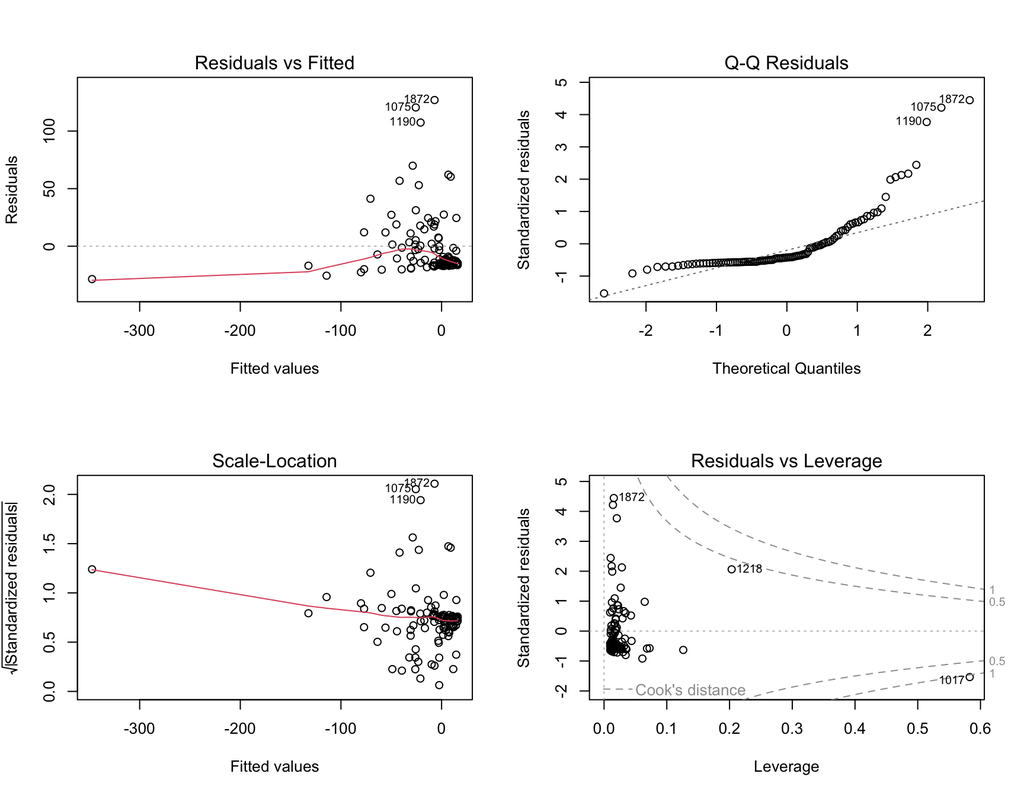

```r
par(mfrow = c(2, 2))
plot(model_3)
```

```r
par(mfrow = c(1, 1))
```

# 8 Managerial Conclusions & Deployment